# INFOSYS SPRINGBOARD

## Building Anomaly Detection System using Python

## Problem Statement:

In this project, we delve deep into the thriving sector of **Security** by analyzing a **Anomaly detection on Healthcare Dataset** from a USA-based Health Service Providers, available at the kaggle. This dataset documents all transactions between patients and service providers. Our primary objective is to amplify the efficiency of Healthcare System and avoid fraudulent transactions in **Healthcare system**. We aim to transform the data into a -centric dataset that will facilitate the Base for Anomaly Detection system of patient providing better service , ultimately enhancing security ,efficiency and patient service.

```python
#importing necessary libraries
#loading dataset

import pandas as pd
import matplotlib.pyplot as plt
import seaborn as sns
import numpy as np
import statistics
from matplotlib.colors import LinearSegmentedColormap
from sklearn.ensemble import IsolationForest
from sklearn.preprocessing import StandardScaler
import category_encoders as ce
from sklearn.decomposition import PCA
from sklearn.cluster import KMeans
from sklearn.cluster import DBSCAN

hdata = pd.read_csv(r'C:\Users\tmbha\Downloads\ifosys_springboard\df_processed.csv')
```

```python
hdata.info()
```

```
<class 'pandas.core.frame.DataFrame'>
RangeIndex: 100000 entries, 0 to 99999
Data columns (total 20 columns):
 #   Column                                                    Non-Null Count   Dtype
---  ------                                                    --------------   -----
 0   Credentials of the Provider                               100000 non-null  object
 1   Gender of the Provider                                    100000 non-null  object
 2   Entity Type of the Provider                               100000 non-null  object
 3   City of the Provider                                      100000 non-null  object
 4   State Code of the Provider                                100000 non-null  object
 5   Country Code of the Provider                              100000 non-null  object
 6   ProviderType                                              100000 non-null  object
 7   Medicare Participation Indicator                          100000 non-null  object
 8   Place of Service                                          100000 non-null  object
 9   HCPCS Description                                         100000 non-null  object
 10  HCPCS Drug Indicator                                      100000 non-null  object
 11  Number of Services                                        100000 non-null  float64
 12  Number of Medicare Beneficiaries                          100000 non-null  int64
 13  Number of Distinct Medicare Beneficiary/Per Day Services  100000 non-null  int64
 14  Average Medicare Allowed Amount                           100000 non-null  float64
 15  Average Submitted Charge Amount                           100000 non-null  float64
 16  Average Medicare Payment Amount                           100000 non-null  float64
 17  Average Medicare Standardized Amount                      100000 non-null  float64
 18  Name                                                      100000 non-null  object
 19  Full Address                                              100000 non-null  object
dtypes: float64(5), int64(2), object(13)
memory usage: 15.3+ MB
```

```python
hdata.describe(include='object')
```

|  | Credentials of the Provider | Gender of the Provider | Entity Type of the Provider | City of the Provider | State Code of the Provider | Country Code of the Provider | ProviderType | Medicare Participation Indicator | Place of Service | HCPCS Description | HCPCS Drug Indicator | Name | Full Address |
| --- | --- | --- | --- | --- | --- | --- | --- | --- | --- | --- | --- | --- | --- |
| count | 100000 | 100000 | 100000 | 100000 | 100000 | 100000 | 100000 | 100000 | 100000 | 100000 | 100000 | 100000 | 100000 |
| unique | 1539 | 2 | 2 | 5846 | 58 | 4 | 90 | 2 | 2 | 2455 | 2 | 87469 | 63853 |
| top | MD | M | I | NEW YORK | CA | US | Diagnostic Radiology | Y | O | Established patient office or other outpatient... | N | WALGREEN CO | 200 1ST ST SW |
| freq | 73827 | 70895 | 95746 | 1061 | 7775 | 99994 | 12537 | 99969 | 61616 | 4578 | 93802 | 362 | 241 |

# Step 5 | Feature Engineering

```python
#generating new feature name Diff_submitted_allowed column in our dataset

hdata['Diff_submitted_allowed'] = hdata['Average Submitted Charge Amount'] - hdata['Average Medicare Allowed Amount']

# Create a binary column indicating whether the customer is from the UK or not
hdata['Is_US'] = hdata['Country Code of the Provider'].apply(lambda x: 1 if x == 'US' else 0)

# Create a binary column indicating Gender of the Provider
hdata['Gender'] = hdata['Gender of the Provider'].apply(lambda x: 1 if x == 'M' else 0)

# Create a binary column indicating Entity Type of the Provider
hdata['Entity'] = hdata['Entity Type of the Provider'].apply(lambda x: 1 if x == 'I' else 0)

# Create a binary column indicating Medicare Participation Indicator
hdata['Medicare_Participation_Indicator'] = hdata['Medicare Participation Indicator'].apply(lambda x: 1 if x == 'Y' else 0)

# Create a binary column indicating Place of Service
hdata['Place_of_Service'] = hdata['Place of Service'].apply(lambda x: 1 if x == 'O' else 0)

# Create a binary column indicating Place of Service
hdata['HCPCS_Drug_Indicator'] = hdata['HCPCS Drug Indicator'].apply(lambda x: 1 if x == 'N' else 0)

DropCols = ['Country Code of the Provider','Gender of the Provider','Entity Type of the Provider','Medicare Participation Indicator',
           'Place of Service','HCPCS Drug Indicator']
hdata = hdata.drop(DropCols, axis = 1)
```

```python
hdata.head().T
```

|  | 0 | 1 | 2 | 3 | 4 |
| --- | --- | --- | --- | --- | --- |
| Credentials of the Provider | MD | MD | DPM | MD | DO |
| City of the Provider | SAINT LOUIS | FAYETTEVILLE | NORTH HAVEN | KANSAS CITY | JUPITER |
| State Code of the Provider | MO | NC | CT | MO | FL |
| ProviderType | Internal Medicine | Obstetrics & Gynecology | Podiatry | Internal Medicine | Internal Medicine |
| HCPCS Description | Initial hospital inpatient care, typically 70 ... | Screening mammography, bilateral (2-view study... | Established patient home visit, typically 25 m... | Urinalysis, manual test | Injection beneath the skin or into muscle for ... |
| Number of Services | 27.0 | 175.0 | 32.0 | 20.0 | 33.0 |
| Number of Medicare Beneficiaries | 24 | 175 | 13 | 18 | 24 |
| Number of Distinct Medicare Beneficiary/Per Day Services | 27 | 175 | 32 | 20 | 31 |
| Average Medicare Allowed Amount | 200.587778 | 123.73 | 90.65 | 3.5 | 26.52 |
| Average Submitted Charge Amount | 305.211111 | 548.8 | 155.0 | 5.0 | 40.0 |
| Average Medicare Payment Amount | 157.262222 | 118.83 | 64.439688 | 3.43 | 19.539394 |
| Average Medicare Standardized Amount | 160.908889 | 135.315257 | 60.595937 | 3.43 | 19.057576 |
| Name | UPADHYAYULA SATYASREE | JONES WENDY P | DUROCHER RICHARD W | FULLARD JASPER | PERROTTI ANTHONY E |
| Full Address | 1402 S GRAND BLVD FDT 14TH FLOOR | 2950 VILLAGE DR | 20 WASHINGTON AVE STE 212 | 5746 N BROADWAY ST | 875 MILITARY TRL SUITE 200 |
| Diff_submitted_allowed | 104.623333 | 425.07 | 64.35 | 1.5 | 13.48 |
| Is_US | 1 | 1 | 1 | 1 | 1 |
| Gender | 0 | 0 | 1 | 1 | 1 |
| Entity | 1 | 1 | 1 | 1 | 1 |
| Medicare_Participation_Indicator | 1 | 1 | 1 | 1 | 1 |
| Place_of_Service | 0 | 1 | 1 | 1 | 1 |
| HCPCS_Drug_Indicator | 1 | 1 | 1 | 1 | 1 |

### Inferences from the Feature Engineering :

- Created a new column name **Diff_submitted_allowed** which shows the difference between average allowed medicare amount and average submitted charge amount .
- There is existing column named Country Code of the Provider which had 4 unique values but the entire data is dominated by US covering 100% proportion of entire column henced created a new feature column **Is_US** and converted it in numeric data type(Boolean) and dropped existing column
- Converted categorical columns which have only two unique values to **binary** columns such as **Gender, Entity type, Medicare_Participation_Indicator,Place_of_Service, HCPCS_Drug_Indicator** to 0 and 1s.

# Step 6 | Frequency Encoding

```python
#encoding categorical variable with frequency encoding
def frequency_encode_columns(df, columns):
    for col in columns:
        frequency_map = df[col].value_counts(normalize=True)
        df[col + '_FrequencyEncoded'] = df[col].map(frequency_map)
    return df

#creating list of categorical columns to encode
columns_to_encode = ['Credentials of the Provider','City of the Provider','State Code of the Provider',
                    'ProviderType','HCPCS Description']

hdata_encoded = frequency_encode_columns(hdata, columns_to_encode)

#Droping the orignal columns for maintaining sigle entries
hdata_encoded = hdata_encoded.drop(columns_to_encode, axis = 1)
```

```python
hdata_encoded.sample(5).T
```

|  | 4617 | 39920 | 96318 | 70736 | 88686 |
| --- | --- | --- | --- | --- | --- |
| Number of Services | 160.0 | 121.0 | 223.0 | 21.0 | 11.0 |
| Number of Medicare Beneficiaries | 103 | 121 | 207 | 20 | 11 |
| Number of Distinct Medicare Beneficiary/Per Day Services | 160 | 121 | 216 | 21 | 11 |
| Average Medicare Allowed Amount | 88.41925 | 37.66 | 8.39 | 238.6 | 163.337273 |
| Average Submitted Charge Amount | 494.975 | 45.0 | 52.825112 | 597.0 | 563.0 |
| Average Medicare Payment Amount | 68.184875 | 28.208595 | 6.480583 | 183.950952 | 128.06 |
| Average Medicare Standardized Amount | 70.652125 | 24.031157 | 6.697892 | 192.440952 | 138.838182 |
| Name | KIM JOSEPH S | NICKLES STEVEN L | KELLY GENE | FORESMAN WILLIAM | DEKKINGA JACK A |
| Full Address | 13700 ST FRANCIS BLVD SUITE 103 | 581 N FRANKLIN TPKE | 2901 N 4TH ST | 192 GENESEE ST | 2660 44TH ST SW STE 100 |
| Diff_submitted_allowed | 406.55575 | 7.34 | 44.435112 | 358.4 | 399.662727 |
| Is_US | 1 | 1 | 1 | 1 | 1 |
| Gender | 1 | 1 | 1 | 1 | 1 |
| Entity | 1 | 1 | 1 | 1 | 1 |
| Medicare_Participation_Indicator | 1 | 1 | 1 | 1 | 1 |
| Place_of_Service | 1 | 1 | 0 | 1 | 1 |
| HCPCS_Drug_Indicator | 1 | 1 | 1 | 1 | 1 |
| Credentials of the Provider_FrequencyEncoded | 0.73827 | 0.06176 | 0.73827 | 0.73827 | 0.73827 |
| City of the Provider_FrequencyEncoded | 0.00043 | 0.00008 | 0.00104 | 0.00082 | 0.00027 |
| State Code of the Provider_FrequencyEncoded | 0.02792 | 0.03333 | 0.06861 | 0.06361 | 0.03516 |
| ProviderType_FrequencyEncoded | 0.03098 | 0.0976 | 0.02377 | 0.01794 | 0.02022 |
| HCPCS Description_FrequencyEncoded | 0.00128 | 0.00018 | 0.0063 | 0.00024 | 0.00014 |

### Inferences from the Feature Encoding :

- Apllied frequency encoding technique to encode high cardinal categorical columns such as **'Credentials of the Provider','City of the Provider','State Code of the Provider','ProviderType','HCPCS Description'** which has more than 50 unique values and some has 1000s of uniquevalues .

# Step 7 | Feature Scaling

```python
# Initialize the StandardScaler
scaler = StandardScaler()

# List of columns that don't need to be scaled
columns_to_exclude = ['Name','Full Address']

# List of columns that need to be scaled
columns_to_scale = hdata_encoded.columns.difference(columns_to_exclude)

# Copy the cleaned dataset
hdata_scaled = hdata_encoded.copy()

# Applying the scaler to the necessary columns in the dataset
hdata_scaled[columns_to_scale] = scaler.fit_transform(hdata_scaled[columns_to_scale])

# Dropping identifiers
DropCols = ['Name','Full Address']
hdata_scaled = hdata_scaled.drop(DropCols, axis = 1)

# Display the first few rows of the scaled data
hdata_scaled.head().T
```

|  | 0 | 1 | 2 | 3 | 4 |
| --- | --- | --- | --- | --- | --- |
| Number of Services | -0.085301 | -0.025939 | -0.083296 | -0.088109 | -0.082895 |
| Number of Medicare Beneficiaries | -0.059308 | 0.076775 | -0.069222 | -0.064716 | -0.059308 |
| Number of Distinct Medicare Beneficiary/Per Day Services | -0.070183 | 0.020049 | -0.067135 | -0.074451 | -0.067744 |
| Average Medicare Allowed Amount | 0.385450 | 0.086673 | -0.041922 | -0.380709 | -0.291221 |
| Average Submitted Charge Amount | -0.046433 | 0.182805 | -0.187794 | -0.328957 | -0.296019 |
| Average Medicare Payment Amount | 0.400082 | 0.207649 | -0.064687 | -0.370166 | -0.289505 |
| Average Medicare Standardized Amount | 0.414299 | 0.286359 | -0.087154 | -0.372921 | -0.294800 |
| Diff_submitted_allowed | -0.166975 | 0.193356 | -0.212261 | -0.282934 | -0.269463 |
| Is_US | 0.007746 | 0.007746 | 0.007746 | 0.007746 | 0.007746 |
| Gender | -1.560716 | -1.560716 | 0.640731 | 0.640731 | 0.640731 |
| Entity | 0.210784 | 0.210784 | 0.210784 | 0.210784 | 0.210784 |
| Medicare_Participation_Indicator | 0.017610 | 0.017610 | 0.017610 | 0.017610 | 0.017610 |
| Place_of_Service | -1.266985 | 0.789275 | 0.789275 | 0.789275 | 0.789275 |
| HCPCS_Drug_Indicator | 0.257051 | 0.257051 | 0.257051 | 0.257051 | 0.257051 |
| Credentials of the Provider_FrequencyEncoded | 0.594983 | 0.594983 | -1.684316 | 0.594983 | -1.549260 |
| City of the Provider_FrequencyEncoded | 1.571686 | 0.189180 | -0.756245 | 0.702275 | -0.561459 |
| State Code of the Provider_FrequencyEncoded | -0.737342 | -0.004973 | -0.989093 | -0.737342 | 1.494517 |
| ProviderType_FrequencyEncoded | 1.336743 | -0.940500 | -0.720441 | 1.336743 | 1.336743 |
| HCPCS Description_FrequencyEncoded | 0.389268 | -0.450300 | -0.608815 | -0.277448 | -0.060785 |

### Inferences from the Feature Scaling :

- Apllied **StandardScalar** to scale the encoded features.
- Also Dropped the identifiers from thedataset such as **'Name','Full Address'**.

# Step 8 | Dimensionality Reduction

### Dimensionality Reduction Method PCA

In this step, we are considering the application of dimensionality reduction techniques to simplify our data while retaining the essential information. Among various methods such as KernelPCA, ICA, ISOMAP, TSNE, and UMAP, I am starting with **PCA (Principal Component Analysis)**. Here's why:

PCA is an excellent starting point because it works well in capturing linear relationships in the data, which is particularly relevant given the multicollinearity we identified in our dataset. It allows us to reduce the number of features in our dataset while still retaining a significant amount of the information, thus making our clustering analysis potentially more accurate and interpretable. Moreover, it is computationally efficient, which means it won't significantly increase the processing time.

However, it's essential to note that we are keeping our options open. After applying PCA, if we find that the first few components do not capture a significant amount of variance, indicating a loss of vital information, we might consider exploring other non-linear methods. These methods can potentially provide a more nuanced approach to dimensionality reduction, capturing complex patterns that PCA might miss, albeit at the cost of increased computational time and complexity.

### Methodology

We will apply PCA on all the available components and plot the cumulative variance explained by them. This process will allow me to visualize how much variance each additional principal component can explain, thereby helping me to pinpoint the optimal number of components to retain for the analysis:

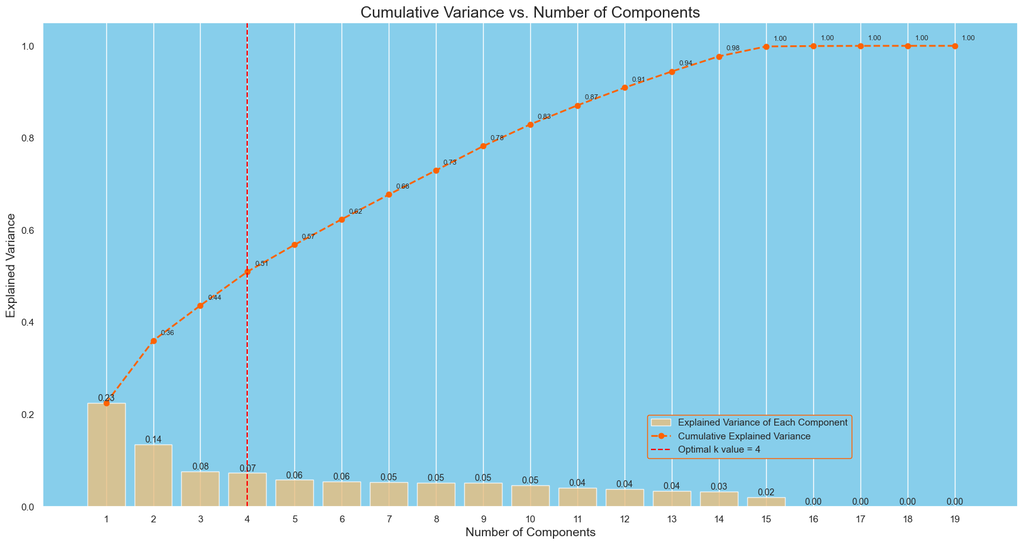

```python
# Apply PCA
pca = PCA().fit(hdata_scaled)

# Calculate the Cumulative Sum of the Explained Variance
explained_variance_ratio = pca.explained_variance_ratio_
cumulative_explained_variance = np.cumsum(explained_variance_ratio)

# Set the optimal k value (based on our analysis, we can choose 6)
optimal_k = 4

# Set seaborn plot style
sns.set(rc={'axes.facecolor': 'skyblue'}, style='darkgrid')

# Plot the cumulative explained variance against the number of components
plt.figure(figsize=(20, 10))

# Bar chart for the explained variance of each component
barplot = sns.barplot(x=list(range(1, len(cumulative_explained_variance) + 1)),
                      y=explained_variance_ratio,
                      color='#fcc36d',
                      alpha=0.8)

# Line plot for the cumulative explained variance
lineplot, = plt.plot(range(0, len(cumulative_explained_variance)), cumulative_explained_variance,
                     marker='o', linestyle='--', color='#ff6200', linewidth=2)

# Plot optimal k value line
optimal_k_line = plt.axvline(optimal_k - 1, color='red', linestyle='--', label=f'Optimal k value = {optimal_k}')

# Set labels and title
plt.xlabel('Number of Components', fontsize=14)
plt.ylabel('Explained Variance', fontsize=14)
plt.title('Cumulative Variance vs. Number of Components', fontsize=18)

# Customize ticks and legend
plt.xticks(range(0, len(cumulative_explained_variance)))
plt.legend(handles=[barplot.patches[0], lineplot, optimal_k_line],
           labels=['Explained Variance of Each Component', 'Cumulative Explained Variance', f'Optimal k value = {optimal_k}'],
           loc=(0.62, 0.1),
           frameon=True,
           framealpha=1.0,
           edgecolor='#ff6200')

# Display the variance values for both graphs on the plots
x_offset = 0.3
y_offset = 0.01
for i, (ev_ratio, cum_ev_ratio) in enumerate(zip(explained_variance_ratio, cumulative_explained_variance)):
    plt.text(i, ev_ratio, f"{ev_ratio:.2f}", ha="center", va="bottom", fontsize=10)
    if i > 0:
        plt.text(i + x_offset, cum_ev_ratio + y_offset, f"{cum_ev_ratio:.2f}", ha="center", va="bottom", fontsize=8)

plt.grid(axis='both')
plt.show()
```

### Conclusion

The plot and the cumulative explained variance values indicate how much of the total variance in the dataset is captured by each principal component, as well as the cumulative variance explained by the first n components.

Here, we can observe that:

- The first component explains approximately 23% of the variance.
- The first two components together explain about 36% of the variance.
- The first three components explain approximately 44% of the variance, and so on.

To choose the optimal number of components, we generally look for a point where adding another component doesn't significantly increase the cumulative explained variance, often referred to as the "**elbow point**" in the curve.

From the plot, we can see that the increase in cumulative variance starts to slow down after the **4th component** (which **captures about 51% of the total variance**).

```python
# Creating a PCA object with 2 components
pca = PCA(n_components=2)

# Fitting and transforming the original data to the new PCA dataframe
data_pca = pca.fit_transform(hdata_scaled)

# Creating a new dataframe from the PCA dataframe, with columns labeled PC1, PC2, etc.
data_pca = pd.DataFrame(data_pca, columns=['PC'+str(i+1) for i in range(pca.n_components_)])

# Displaying the resulting dataframe based on the PCs
data_pca.head(10)
```

|  | PC1 | PC2 |
| --- | --- | --- |
| 0 | 0.435022 | -0.288328 |
| 1 | 0.392231 | 0.052477 |
| 2 | -0.323010 | -0.134462 |
| 3 | -0.868838 | -0.183356 |
| 4 | -0.824890 | -0.188083 |
| 5 | -0.734071 | -0.040215 |
| 6 | -0.470852 | -0.299845 |
| 7 | -0.688050 | -0.095425 |
| 8 | -0.736538 | -0.132574 |
| 9 | -0.369886 | 0.406647 |

# Step 9 | Cluster Visualization

# K-means Clustering

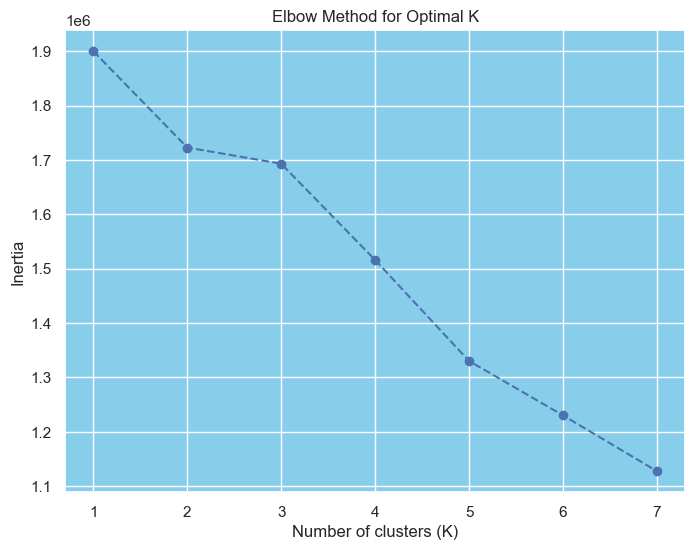

```python
# Initialize a list to store the values of inertia (sum of squared distances)
inertia = []

# Iterate over a range of possible number of clusters
for k in range(1, 8):
    kmeans = KMeans(n_clusters=k, random_state=42)
    kmeans.fit(hdata_scaled)
    inertia.append(kmeans.inertia_)

# Plotting the Elbow curve
plt.figure(figsize=(8, 6))
plt.plot(range(1, 8), inertia, marker='o', linestyle='--')
plt.xlabel('Number of clusters (K)')
plt.ylabel('Inertia')
plt.title('Elbow Method for Optimal K')
plt.show()
```

### Inferences from the Plot :

- The Elbow method plot shows the no of clusters that can be formed with data .
- by observing above graph 2 should be the optimal no of cluster

```python
# Initialize K-means with 2 clusters
kmeans = KMeans(n_clusters=2, random_state=0)
kmeans.fit(hdata_scaled)

# Get cluster labels
cluster_labels = kmeans.labels_

# Assign clusters back to the original DataFrame
hdata_scaled['Cluster'] = cluster_labels
```

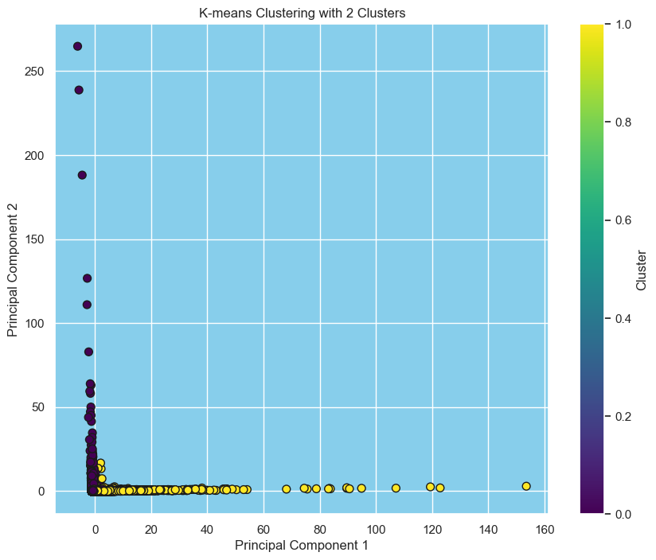

```python
# Create a DataFrame with the principal components and cluster labels
pca_df = pd.DataFrame(data=data_pca, columns=['PC1', 'PC2'])
pca_df['Cluster'] = cluster_labels

# Plot clusters
plt.figure(figsize=(10, 8))
plt.scatter(pca_df['PC1'], pca_df['PC2'], c=pca_df['Cluster'], cmap='viridis', edgecolor='k', s=50)
plt.title('K-means Clustering with 2 Clusters')
plt.xlabel('Principal Component 1')
plt.ylabel('Principal Component 2')
plt.colorbar(label='Cluster')
plt.show()
```

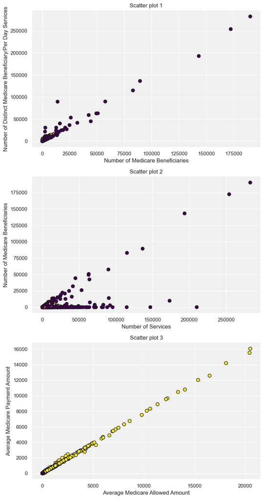

```python
sns.set(rc={'axes.facecolor': '#F0F0F0'}, style='darkgrid')
#visualization on Scatter plots
fig, axs = plt.subplots(3, figsize=(8,15),tight_layout=True)

#plotting Scatter Plots
axs[0].scatter(hdata['Number of Medicare Beneficiaries'], hdata['Number of Distinct Medicare Beneficiary/Per Day Services'], c=pca_df['Cluster'],
               cmap='viridis',edgecolor='k', s=50)
axs[0].set_title('Scatter plot 1')
axs[0].set_xlabel('Number of Medicare Beneficiaries')
axs[0].set_ylabel('Number of Distinct Medicare Beneficiary/Per Day Services')


axs[1].scatter(hdata['Number of Services'], hdata['Number of Medicare Beneficiaries'], c=pca_df['Cluster'],
               cmap='viridis',edgecolor='k', s=50)
axs[1].set_title('Scatter plot 2')
axs[1].set_xlabel('Number of Services')
axs[1].set_ylabel('Number of Medicare Beneficiaries')

axs[2].scatter(hdata['Average Medicare Allowed Amount'], hdata['Average Medicare Payment Amount'], c=pca_df['Cluster'],
               cmap='viridis',edgecolor='k', s=50)
axs[2].set_title('Scatter plot 3')
axs[2].set_xlabel('Average Medicare Allowed Amount')
axs[2].set_ylabel('Average Medicare Payment Amount')

plt.show()
```

# DBSCAN Clustering

```python
DropCols = ['Cluster']
hdata_scaled = hdata_scaled.drop(DropCols, axis = 1)
```

```python
# Initialize DBSCAN
dbscan = DBSCAN(eps=0.5,min_samples=50)
hdata_scaled['Cluster'] = dbscan.fit_predict(hdata_scaled.iloc[:, 1:].to_numpy())

hdata_scaled.sample(5)
```

|  | Number of Services | Number of Medicare Beneficiaries | Number of Distinct Medicare Beneficiary/Per Day Services | Average Medicare Allowed Amount | Average Submitted Charge Amount | Average Medicare Payment Amount | Average Medicare Standardized Amount | Diff_submitted_allowed | Is_US | Gender | Entity | Medicare_Participation_Indicator | Place_of_Service | HCPCS_Drug_Indicator | Credentials of the Provider_FrequencyEncoded | City of the Provider_FrequencyEncoded | State Code of the Provider_FrequencyEncoded | ProviderType_FrequencyEncoded | HCPCS Description_FrequencyEncoded | Cluster |
| --- | --- | --- | --- | --- | --- | --- | --- | --- | --- | --- | --- | --- | --- | --- | --- | --- | --- | --- | --- | --- |
| 59657 | -0.070461 | -0.041284 | -0.047625 | 0.021300 | -0.081437 | 0.018279 | 0.027544 | -0.103467 | 0.007746 | -1.560716 | 0.210784 | 0.01761 | -1.266985 | 0.257051 | 0.594983 | -0.694484 | -1.113698 | 1.336743 | 0.336696 | -1 |
| 41495 | -0.091318 | -0.070123 | -0.079328 | 0.350802 | -0.153280 | 0.553207 | 0.548945 | -0.284621 | 0.007746 | 0.640731 | -4.744185 | 0.01761 | 0.789275 | -3.890275 | 0.594983 | -0.703985 | -0.811935 | -0.895122 | -0.130085 | 48 |
| 27830 | 0.122466 | 0.308388 | 0.245628 | -0.382342 | -0.289368 | -0.372219 | -0.374970 | -0.235159 | 0.007746 | 0.640731 | -4.744185 | 0.01761 | 0.789275 | 0.257051 | 0.594983 | -0.414182 | -1.437500 | -0.893801 | -0.279041 | 4 |
| 1392 | -0.090516 | -0.068321 | -0.078109 | -0.349435 | -0.300993 | -0.342030 | -0.345037 | -0.258567 | 0.007746 | -1.560716 | 0.210784 | 0.01761 | -1.266985 | 0.257051 | 0.594983 | -0.048364 | -0.980617 | 1.594689 | -0.336393 | 19 |
| 12398 | -0.089312 | -0.068321 | -0.076280 | -0.223425 | -0.292292 | -0.258980 | -0.258552 | -0.284621 | 0.007746 | 0.640731 | 0.210784 | 0.01761 | 0.789275 | 0.257051 | 0.594983 | -0.799003 | -1.053939 | 0.982975 | 0.426706 | 1 |

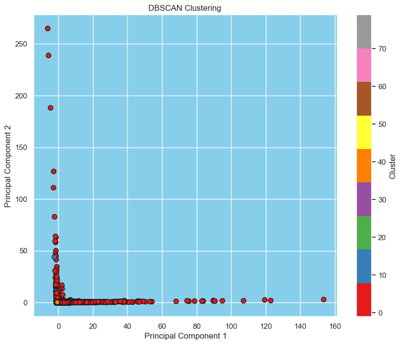

```python
sns.set(rc={'axes.facecolor': 'skyblue'}, style='darkgrid')
# Create a DataFrame with the principal components and cluster labels
pca_df = pd.DataFrame(data=data_pca, columns=['PC1', 'PC2'])
pca_df['Cluster'] = hdata_scaled['Cluster']

# Plot clusters
plt.figure(figsize=(10, 8))
plt.scatter(pca_df['PC1'], pca_df['PC2'], c=pca_df['Cluster'], cmap='Set1', edgecolor='k', s=50)
plt.title('DBSCAN Clustering ')
plt.xlabel('Principal Component 1')
plt.ylabel('Principal Component 2')
plt.colorbar(label='Cluster')
plt.show()
```

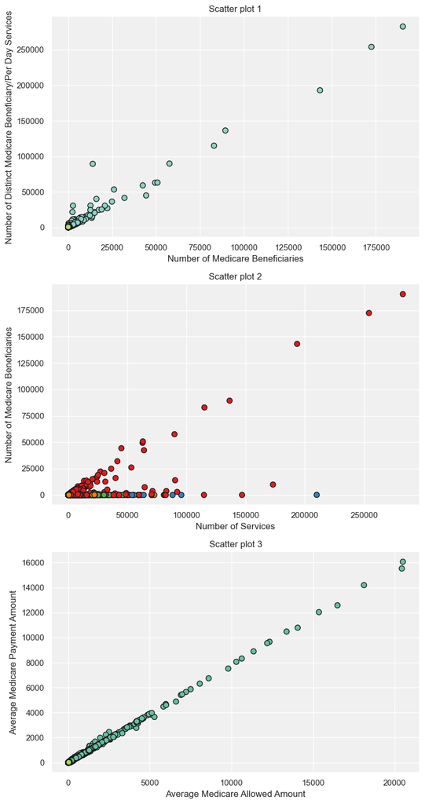

```python
sns.set(rc={'axes.facecolor': '#F0F0F0'}, style='darkgrid')
#visualization on Scatter plots
fig, axs = plt.subplots(3, figsize=(8,15),tight_layout=True)

#plotting Scatter Plots
axs[0].scatter(hdata['Number of Medicare Beneficiaries'], hdata['Number of Distinct Medicare Beneficiary/Per Day Services'], c=pca_df['Cluster'],
               cmap='Set3',edgecolor='k', s=50)
axs[0].set_title('Scatter plot 1')
axs[0].set_xlabel('Number of Medicare Beneficiaries')
axs[0].set_ylabel('Number of Distinct Medicare Beneficiary/Per Day Services')


axs[1].scatter(hdata['Number of Services'], hdata['Number of Medicare Beneficiaries'], c=pca_df['Cluster'],
               cmap='Set1',edgecolor='k', s=50)
axs[1].set_title('Scatter plot 2')
axs[1].set_xlabel('Number of Services')
axs[1].set_ylabel('Number of Medicare Beneficiaries')

axs[2].scatter(hdata['Average Medicare Allowed Amount'], hdata['Average Medicare Payment Amount'], c=pca_df['Cluster'],
               cmap='Set2',edgecolor='k', s=50)
axs[2].set_title('Scatter plot 3')
axs[2].set_xlabel('Average Medicare Allowed Amount')
axs[2].set_ylabel('Average Medicare Payment Amount')

plt.show()
```

### Inferences from the Scatter Plot :

- scatter plot 2 shows that multiple clusters are on lower boundaries .
- in scatter plot 3 the Average Medicare Allowed Amount against Average Medicare Payment Amount where cluster point are positively related showing linear characters